# What drives the functional response to logging in Amazonia?

In this study we model the functional resistance and resilience of trees recruitement to disturbance (here selective logging), and their spatial variation in Amazonia.

# Data visualisation

## Traits trajectory

Traits chosen:

- $DBH95$: DBH 95th percentile (per species) as a proxy of the stature
- $logSeedMass$: median seed mass (log-transformed) as a proxy of the dispersal strategy
- $SLA$: median specific leaf area, as a proxy of the assimilation strategy and leaf economic spectrum
- $WD$: median wood density, as a proxy of growth rate and mechanical support

We separate two size classes:

- Small trees, ie trees $\leq$ 35 cm dbh
- Big trees, ie trees $>$ 35 cm dbh

Here are represented for each size class the mean trait value, weighted by the estimated above ground biomass (AGB) of each individual.

### Jenaro

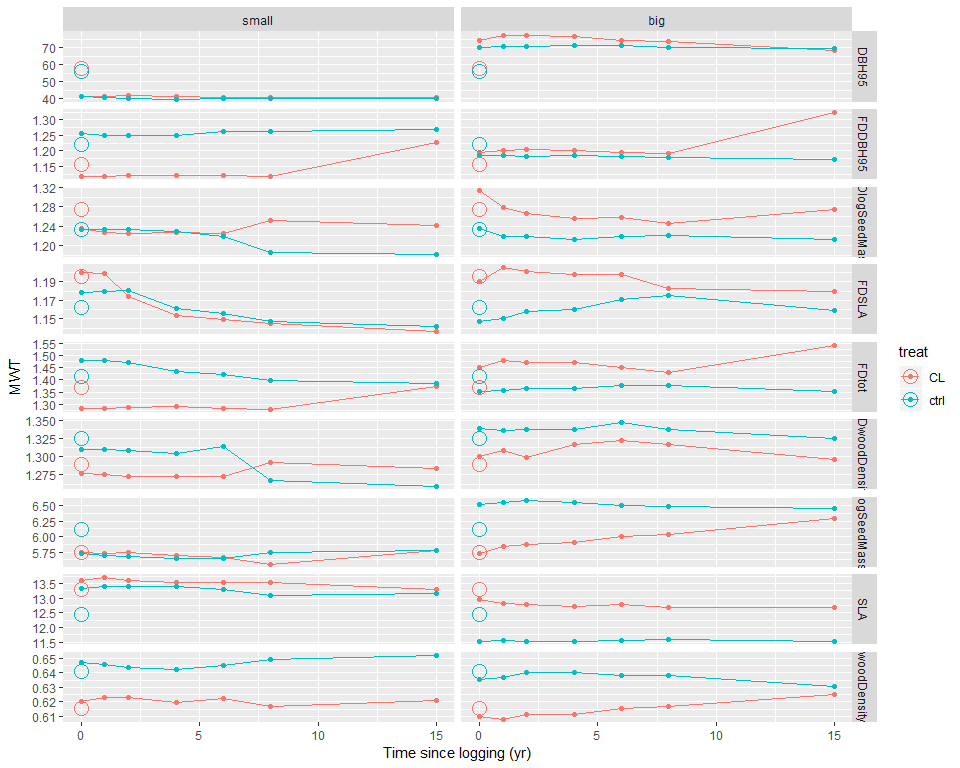

### Chico Bocao

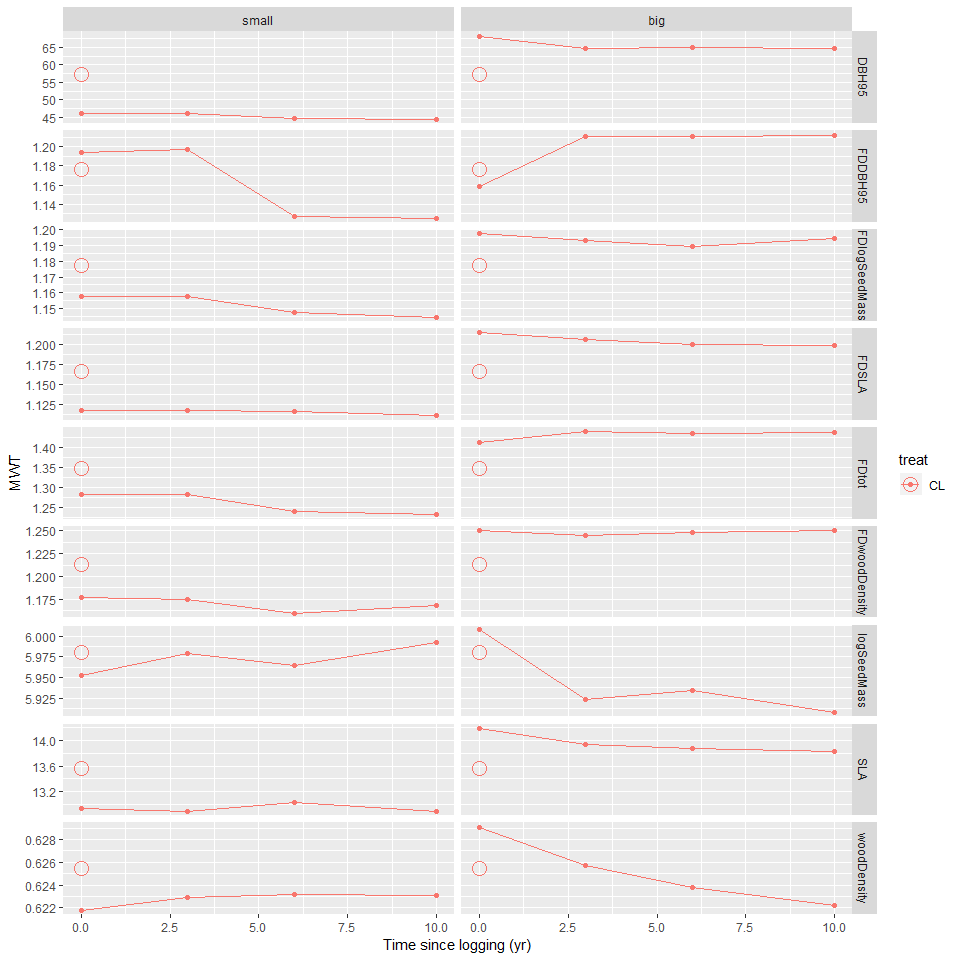

### Cumaru

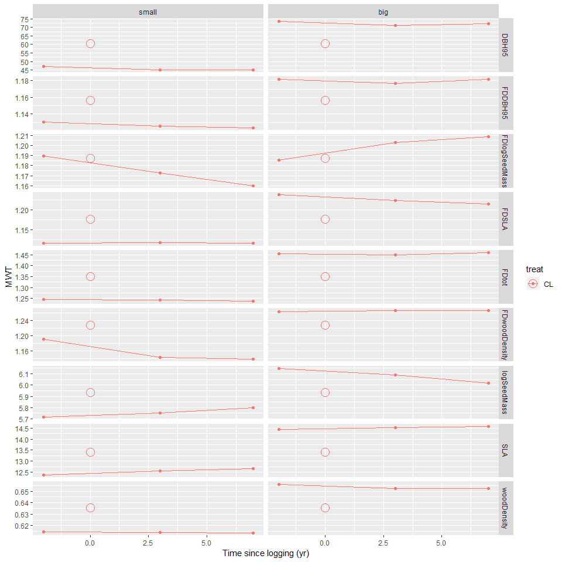

### INPA

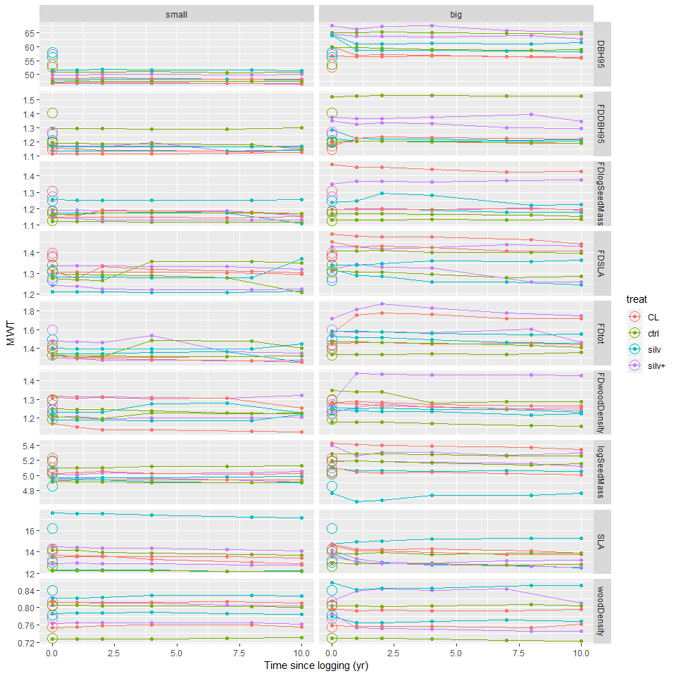

### Iracema

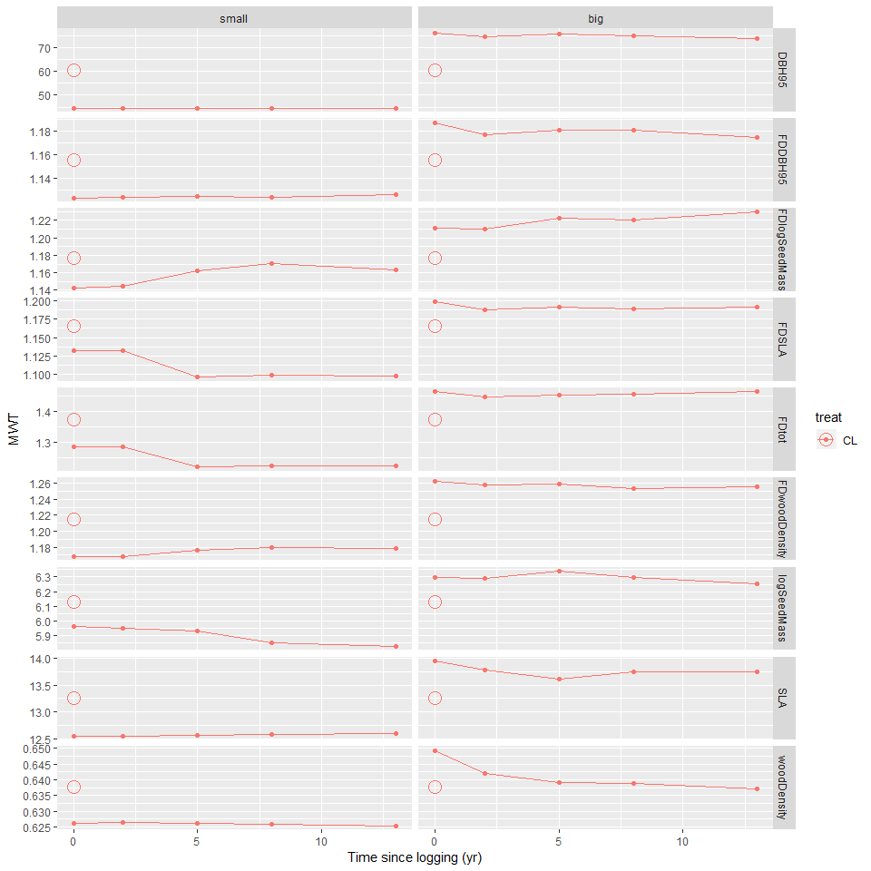

### La Chonta

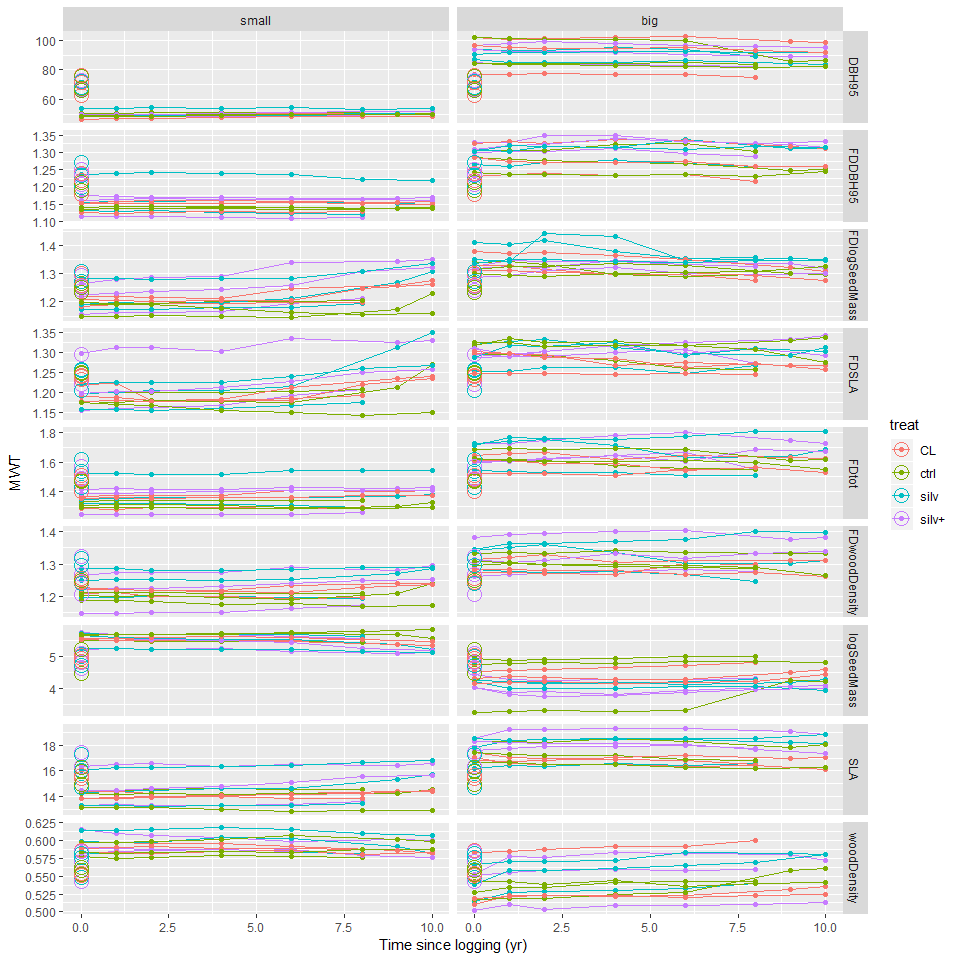

### Peteco

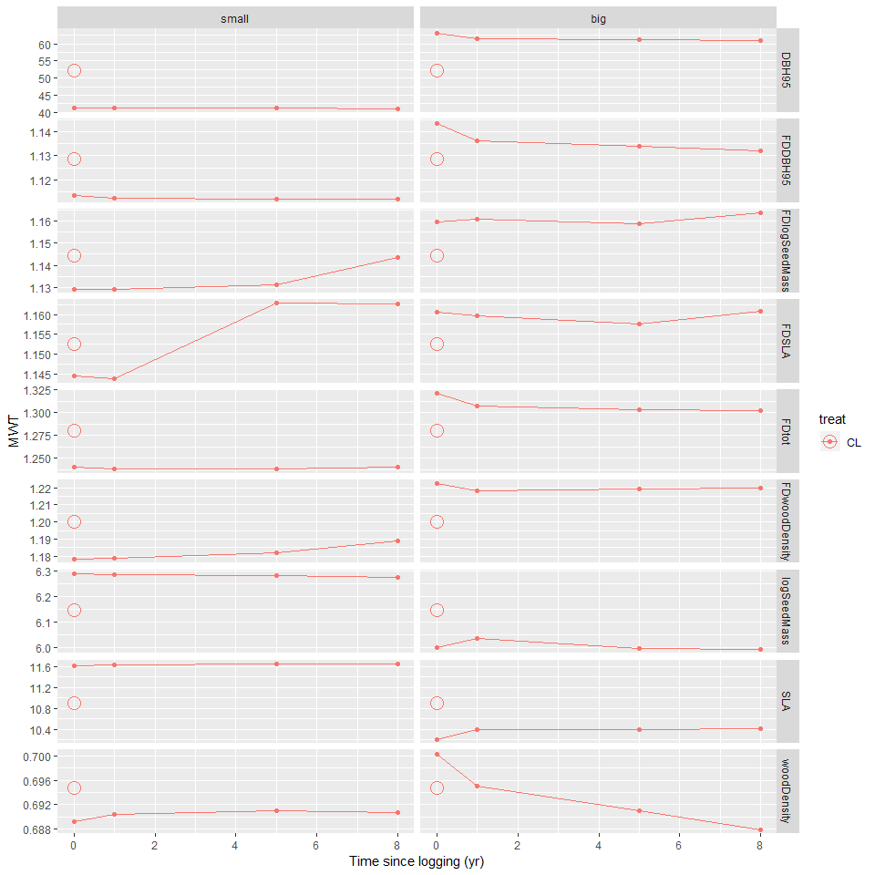

### Paracou

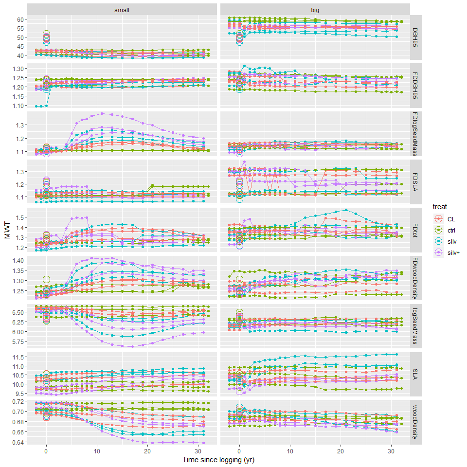

### Paragominas

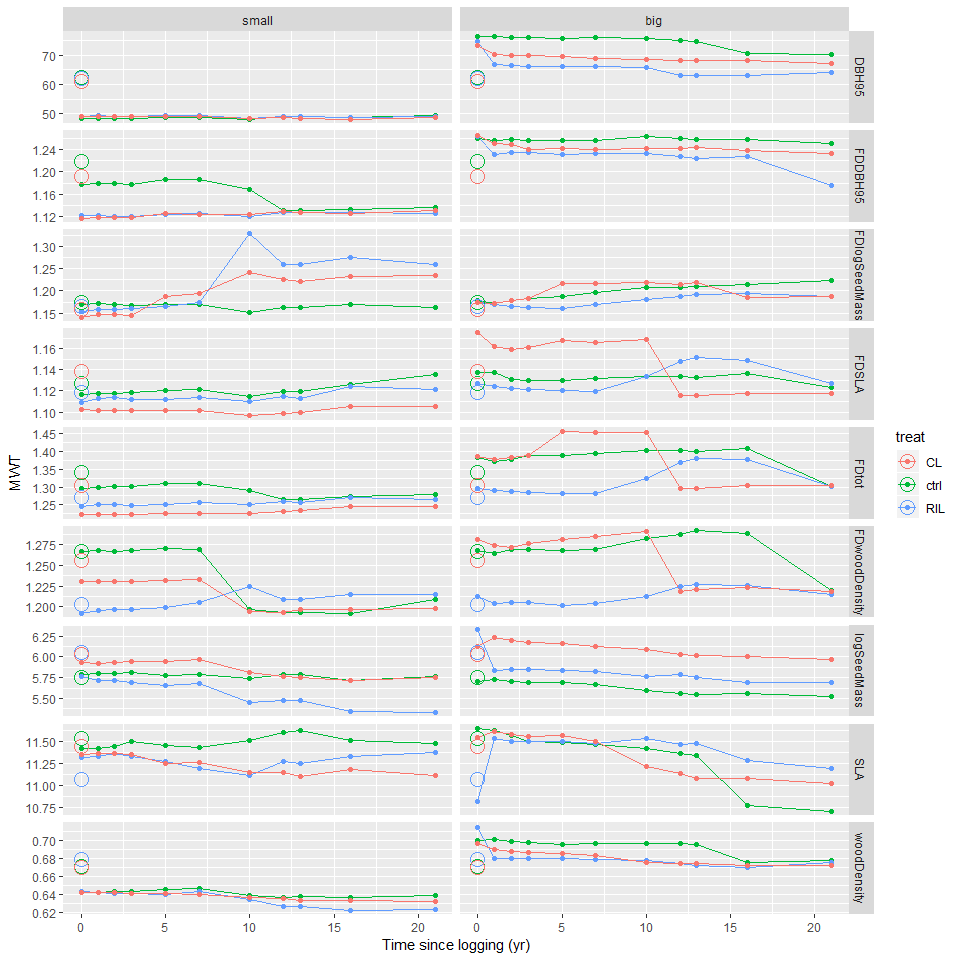

### Tabocal

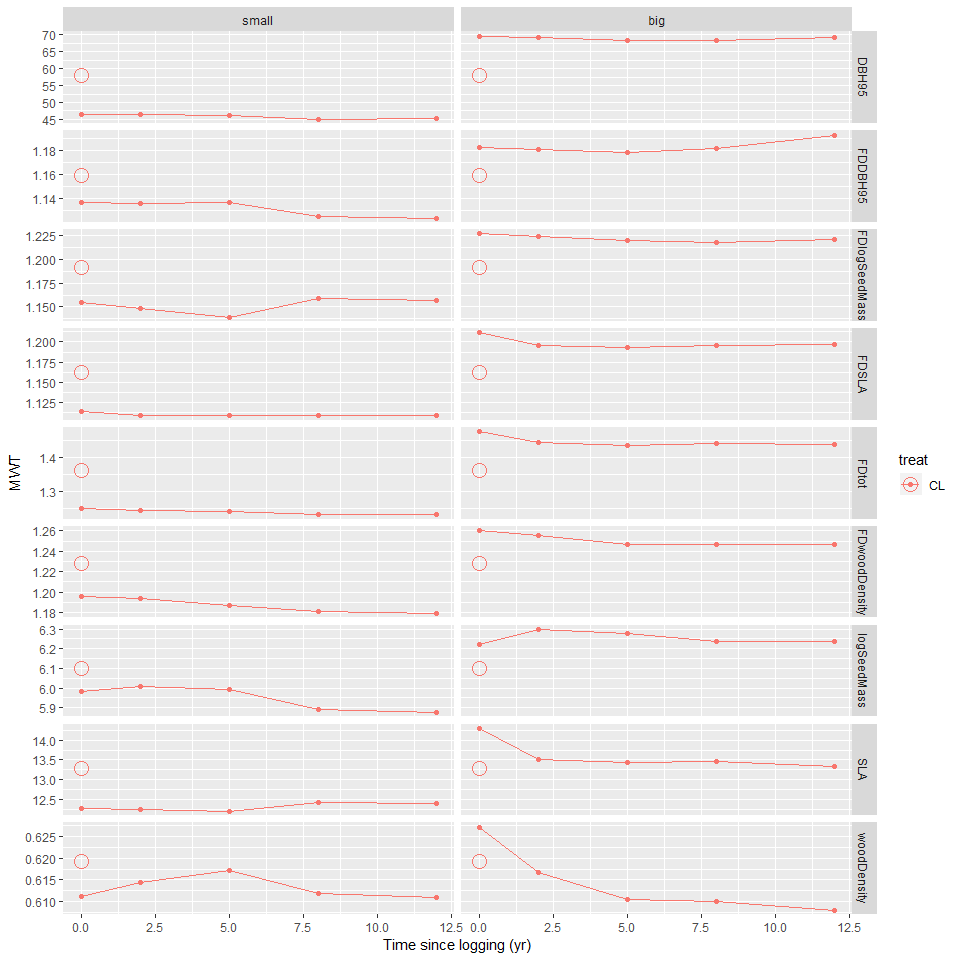

### Tapajos

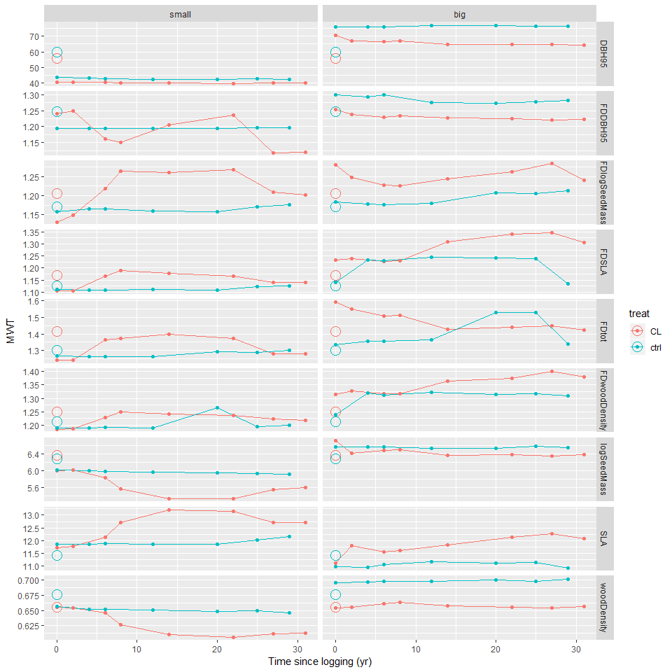

### Tortue

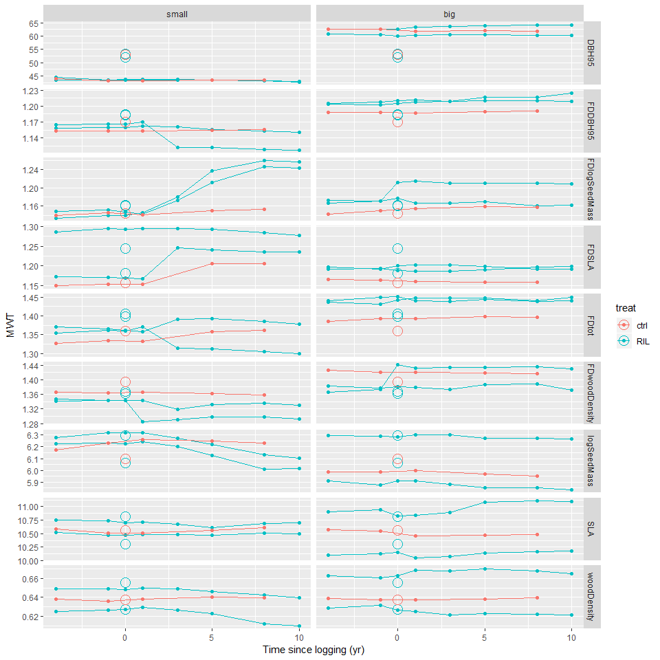

## Recruits most common genuses and their impact on mean weighted traits

### Jenaro

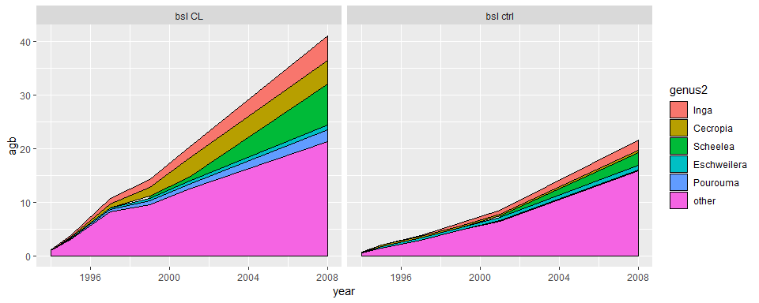

### Chico Bocao

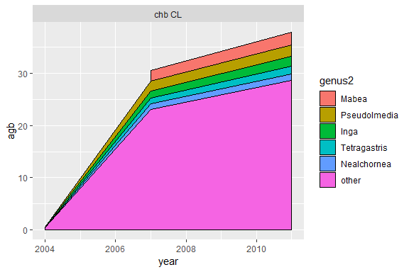

### Cumaru

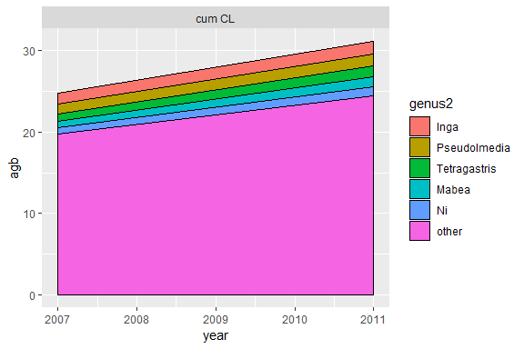

### INPA

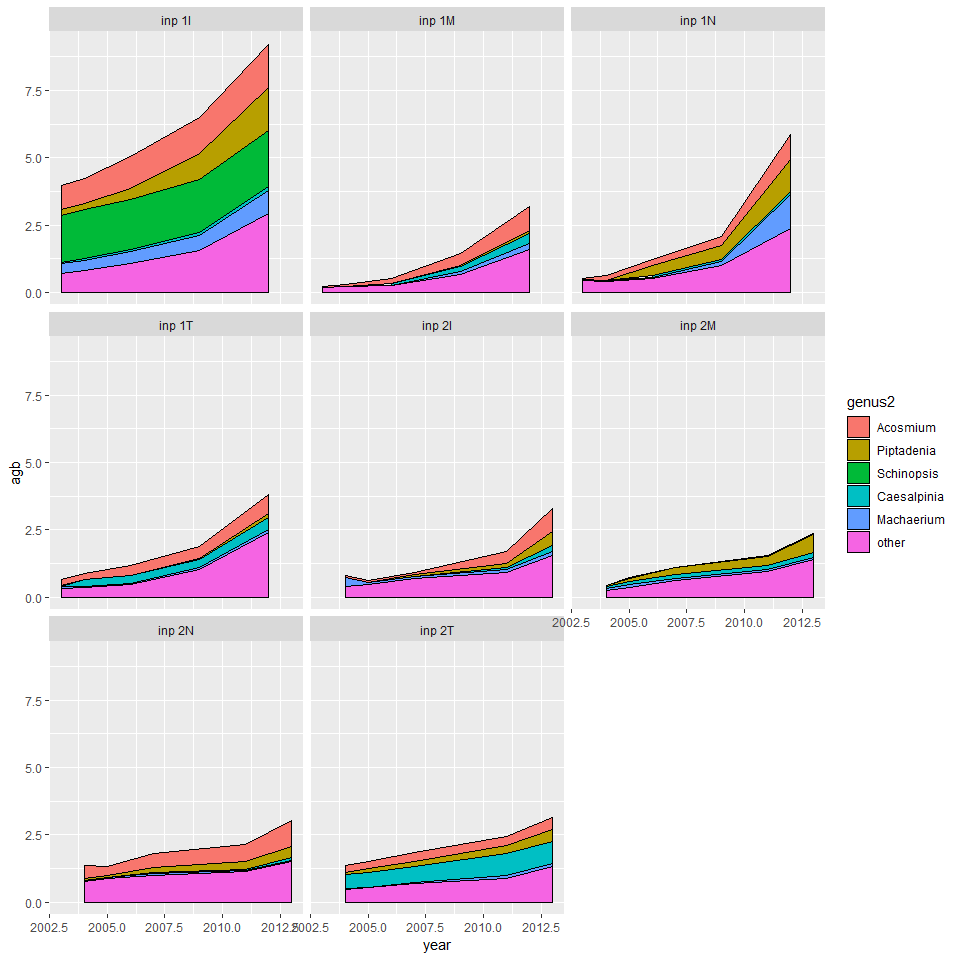

### Iracema

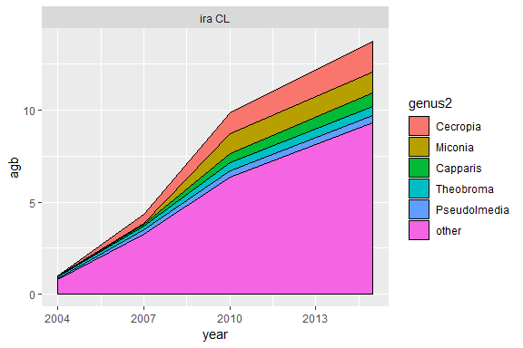

### La Chonta

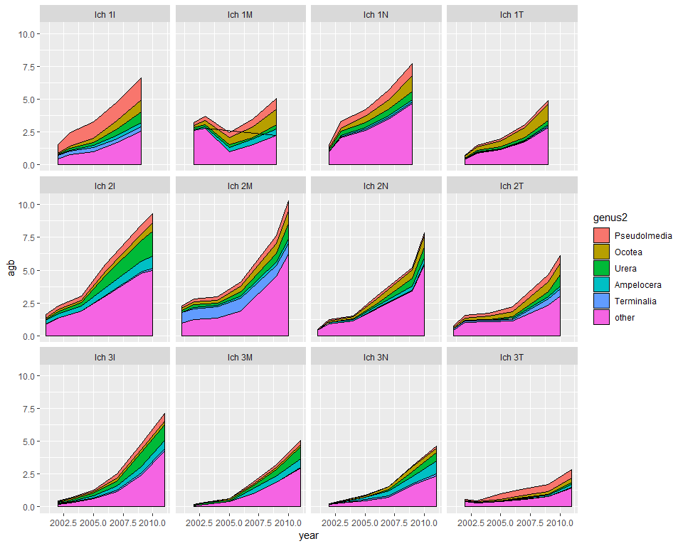

### Peteco

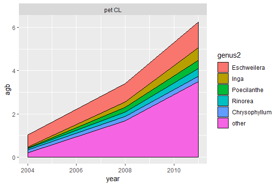

### Paracou

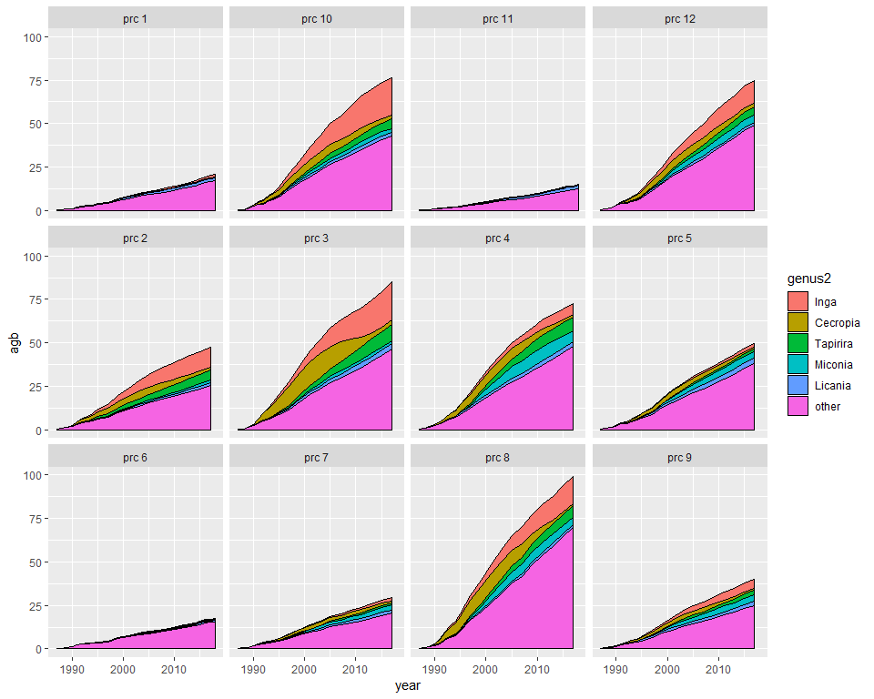